# Project Milestone: Project Proposal

# Data Sets (3/10): Census

[figure not shown]

Source: [`tidycensus`](https://walker-data.com/tidycensus/)

# Data Sets (4/10): Jeopardy

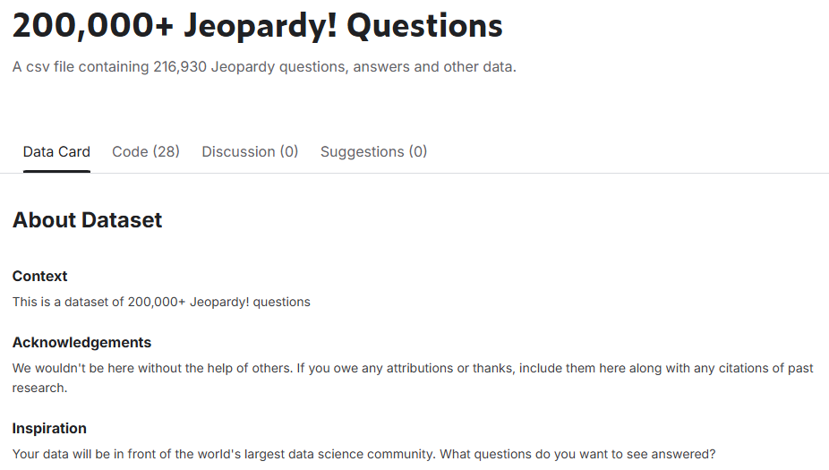

Source: [200,000+ Jeopardy! Questions](https://www.kaggle.com/datasets/tunguz/200000-jeopardy-questions)

# Data Sets (5/10): Spotify Songs

[figure not shown]

Source: [Spotify Million Song Dataset (Kaggle)](https://www.kaggle.com/datasets/notshrirang/spotify-million-song-dataset)

# Data Sets (6/10): Fake News

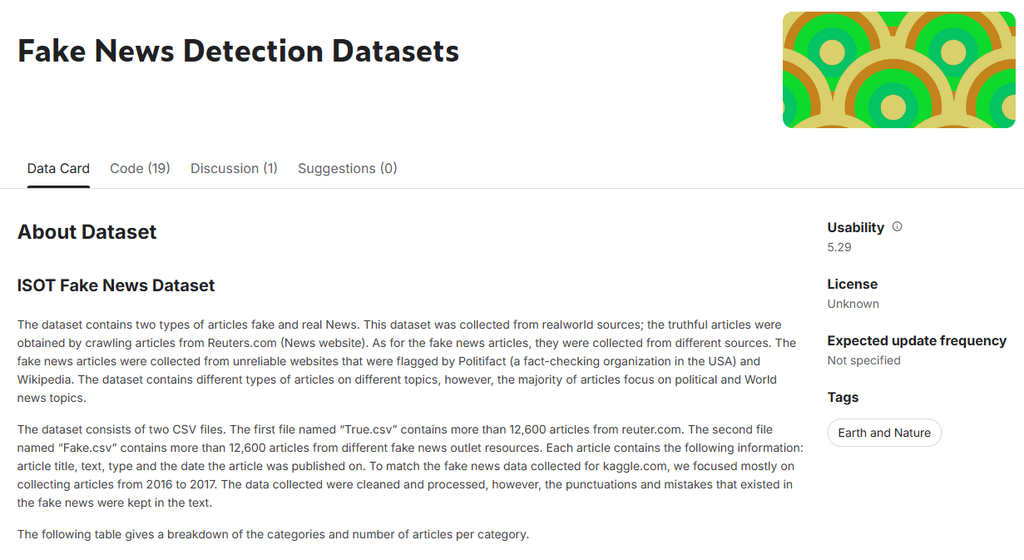

Source: [Fake News detection dataset (Kaggle)](https://www.kaggle.com/datasets/emineyetm/fake-news-detection-datasets)

# Data Sets (7/10): Spam Emails

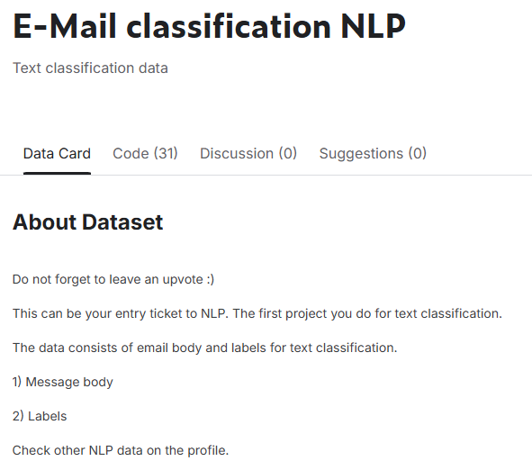

Source: [E-Mail classification NLP (Kaggle)](https://www.kaggle.com/datasets/datatattle/email-classification-nlp)

# Data Sets (8/10): Apps

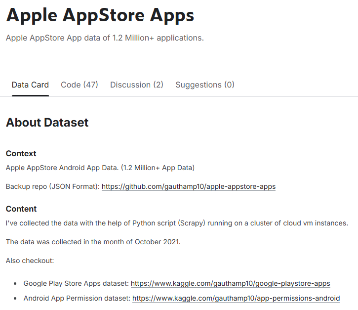

[figure not shown]

Source 1: [Apple AppStore Apps (Kaggle)](https://www.kaggle.com/datasets/gauthamp10/apple-appstore-apps) Source 2: [Google Play Store Apps (Kaggle)](https://www.kaggle.com/datasets/lava18/google-play-store-apps)

# Data Sets (9/10): Movies

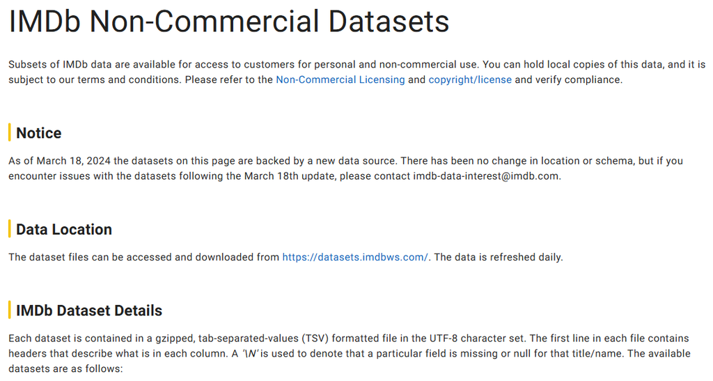

Source: [IMDb Non-Commercial Datasets](https://developer.imdb.com/non-commercial-datasets/)

# Data Sets (10/10): Twitter

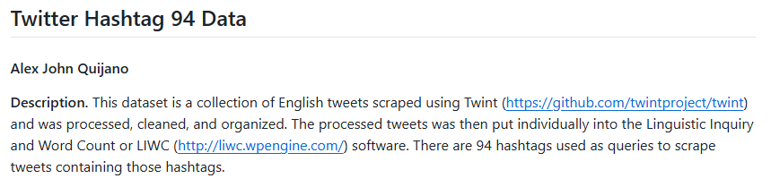

Source: [Twitter Hashtag 94 Data](https://github.com/stressosaurus/processed-data-twitter-hashtag94)

# Project Proposal

**Frame your data science project, establish objectives, and outline the approach to solving it. Requirements:**

- Clearly define the problem or research question.
- Specify the dataset(s) to be used and their relevance.
- Outline the methods or techniques to be employed (e.g., exploratory data analysis, modeling, visualization).

**While you think about your proposal, here are key contents that must exist in your overall project:**

- Data wrangling of a main data set and multiple secondary related data sets
- Data visualization of common plots and with at least one of each type such as temporal, spatial, and network plots
- (Optional) Mathematical/Statistical modeling and/or inference

# Activity: Getting Started with your Project

1. Log-in to Posit Cloud and open the R Studio assignment `Project AlexQ`.
2. Replace the project name `Project AlexQ` to your name using the format `Project [First name][Last initial]`.
3. Create a new RMarkdown file and modify it with your name. Remove the default texts.
4. Choose one data set in the given list. In your Rmarkdown file, provide the following information:
   - Define your problem or research question
   - Specify the dataset(s) to be used and their relevance
   - Outline the methods or techniques to be employed
5. When finished, knit your `.Rmd` to `.html`, and create a 3-slide presentation that summarizes your report, then Submit your work to Moodle.

$\star$ Your report (`.Rmd`, `.html`, and the 3-slide presentation) for this milestone will be due on the next milestone of the project. The in-between phases will serve as check-ins.